# Bivariate Data: 2-S Tests for Means

For MATH50XX by ctong

## Import Data

### **Import Data**

Download the end of year HR data file [**eoyHR.xlsx**] from Blackboard.

This Excel workbook contains 2 worksheets:

- **Data:** Data compiled by the HR department of a publishing company
- **Dictionary:** Data dictionary for variables included in the **Data** worksheet

Adapt the following code to import the data into a data frame named `dfHR`. If you have not already installed the `readxl` package, run `install.packages("readxl")` before proceeding.

```r
library (readxl)
dfHR <- as.data.frame(read_excel("eoyHR.xlsx", sheet = "Data"))
head (dfHR) # displays the first few lines of dfHR
```

```
##   City      Education ProfDev HrPay   Income PerfPrev PerfCurr Satis BenePrev
## 1    1 Post-Secondary      No 29.01 52802.20     7.78     7.54  8.95     3095
## 2    3 Post-Secondary     Yes 27.26 49620.04     5.94     9.66  9.00     2651
## 3    2      Secondary      No 29.40 53503.69     5.73     6.76  8.99     1174
## 4    1 Post-Secondary     Yes 27.45 49953.31     5.10     6.19  9.31     3020
## 5    1      Secondary      No 27.50 50043.81     7.31     7.35  8.45     1180
## 6    3 Post-Secondary     Yes 30.07 54721.95     7.15     6.86  8.95     3305
##   BeneCurr Action
## 1     4024   None
## 2     3446  Bonus
## 3     1526   None
## 4     3926   None
## 5     1534   None
## 6     4297   None
```

## Compare Independent Samples

### **Independent Samples t-Test for Means**

#### **Test description**

Compares the mean of a scale DV across 2 levels of a categorical IV.

E.g., Compare the mean incomes between residents of British Columbia versus Ontario

- DV = income (scale variable)
- IV = province (categorical variable with 2 levels: BC versus ON)

#### **Assumptions**

- DV is a scale variable
- IV is a categorical variable which categorizes observations into 2 independent groups
- Independence of observations
- DV has no outliers in each group
- DV is normally distributed in each group
- Homogeneity of variance for DV between the two groups

#### **R syntax**

*2-tailed test*

- $H_0: \mu_1 = \mu_2$
- $H_1: \mu_1 \neq \mu_2$

`t.test(y1, y2, paired=FALSE, var.equal=TRUE, alternative="two.sided")`

*1-tailed tests*

- $H_0: \mu_1 \geq \mu_2$
- $H_1: \mu_1 < \mu_2$

`t.test(y1, y2, paired=FALSE, var.equal=TRUE, alternative="less")`

- $H_0: \mu_1 \leq \mu_2$
- $H_1: \mu_1 > \mu_2$

`t.test(y1, y2, paired=FALSE, var.equal=TRUE, alternative="greater")`

**Notes:**

- `paired=FALSE` indicates an independent (or unpaired) samples t-test.
- `var.equal=TRUE` indicates that the homogeneity of variance assumption is met. If the assumption is violated, set `var.equal=FALSE` to perform a Welch’s t-test which accommodates unequal variances.
- There is an alternate syntax for independent groups t-test which uses the `~` operator. This will be discussed in the next course.
  - `t.test(y ~ x, data = myDF, paired = FALSE, alternative = "two.sided")`

#### **Non-parametric alternative**

The Wilcoxon Rank Sum test is a non-parametric alternative to the Independent Samples t-test when the normality assumption is violated. It compares the medians of two independent samples.

- `wilcox.test(y1, y2, paired = FALSE, alternative="two.sided")`
- `wilcox.test(y1, y2, paired = FALSE, alternative="less")`
- `wilcox.test(y1, y2, paired = FALSE, alternative="greater")`

#### **Sample analysis**

Did employees in BC (Victoria and Vancouver) have significantly higher incomes than ON (Toronto and Ottawa) employees?

*Identify the null and alternate hypotheses*

1-tailed test:

$H_0: \mu_{bc} \leq \mu_{on}$

$H_1: \mu_{bc} > \mu_{on}$

*[Optional] Create fresh copy of data frame*

```r
myDF <- dfHR
```

*Create a new categorical variable of Province with two levels: BC vs ON*

```r
myDF$Province[myDF$City==3|myDF$City==4]="BC"
myDF$Province[myDF$City==1|myDF$City==2]="ON"
head(myDF)
```

```
##   City      Education ProfDev HrPay   Income PerfPrev PerfCurr Satis BenePrev
## 1    1 Post-Secondary      No 29.01 52802.20     7.78     7.54  8.95     3095
## 2    3 Post-Secondary     Yes 27.26 49620.04     5.94     9.66  9.00     2651
## 3    2      Secondary      No 29.40 53503.69     5.73     6.76  8.99     1174
## 4    1 Post-Secondary     Yes 27.45 49953.31     5.10     6.19  9.31     3020
## 5    1      Secondary      No 27.50 50043.81     7.31     7.35  8.45     1180
## 6    3 Post-Secondary     Yes 30.07 54721.95     7.15     6.86  8.95     3305
##   BeneCurr Action Province
## 1     4024   None       ON
## 2     3446  Bonus       BC
## 3     1526   None       ON
## 4     3926   None       ON
## 5     1534   None       ON
## 6     4297   None       BC
```

*Create variable for income in each province*

```r
bcIncome = myDF$Income[myDF$Province=="BC"]
onIncome = myDF$Income[myDF$Province=="ON"]
```

*Test for outliers in each province*

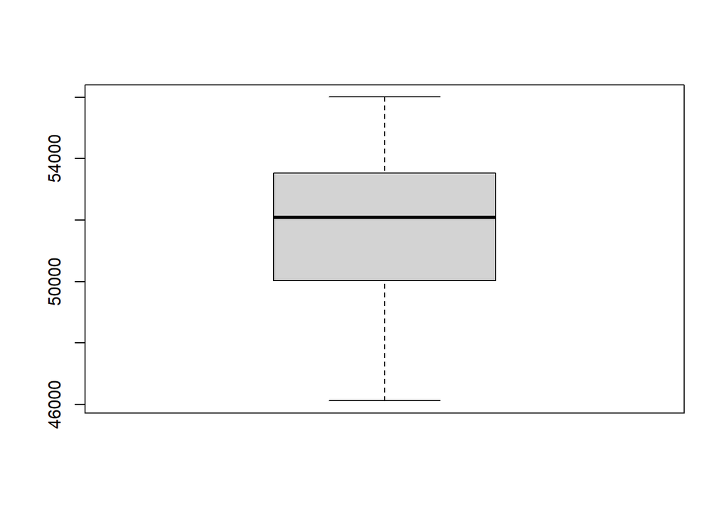

```r
bcIncomeOutliers = boxplot(bcIncome)$out
```

No outliers in `bcIncome`

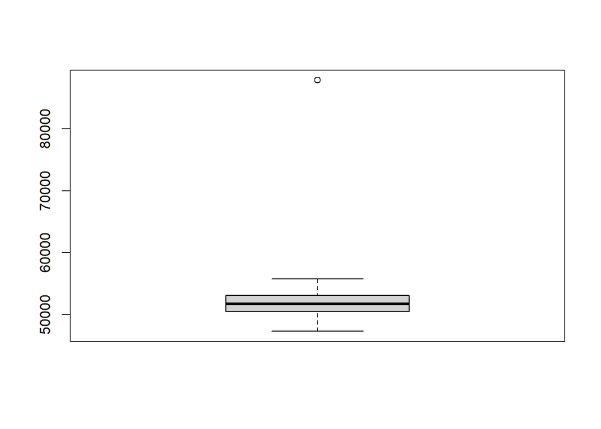

```r
onIncomeOutliers = boxplot(onIncome)$out
```

```r
onIncomeOutliers
```

```
## [1] 87808.75
```

Remove outlier from `onIncome`. Be sure to check that the number of observations in `onIncome` decreased by 1. Then re-run boxplot to confirm that there are no other outliers.

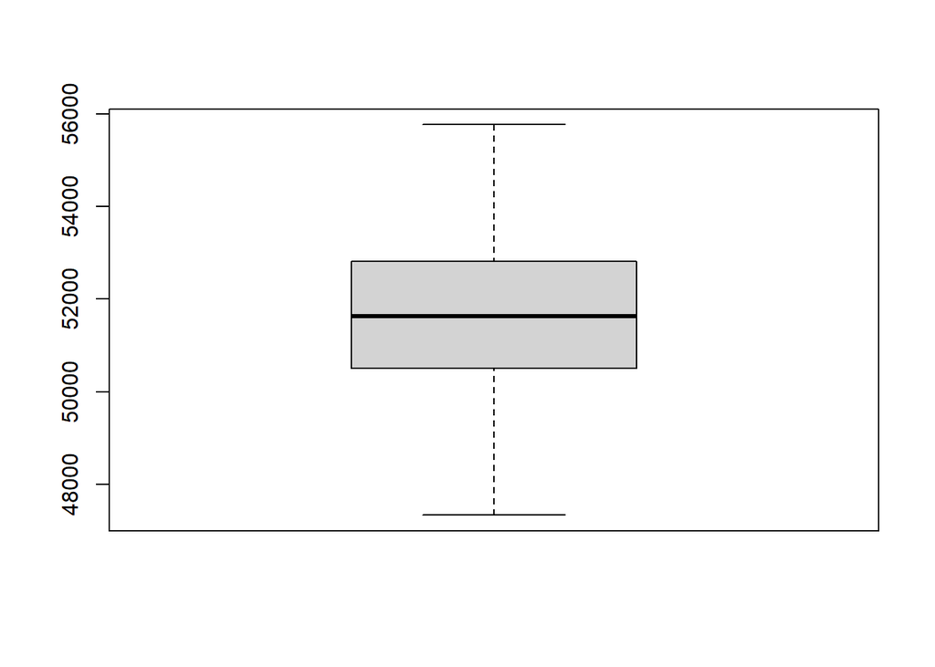

```r
onIncome = onIncome[!(onIncome %in% onIncomeOutliers)]
boxplot(onIncome)
```

*Visualize the data for the two provinces*

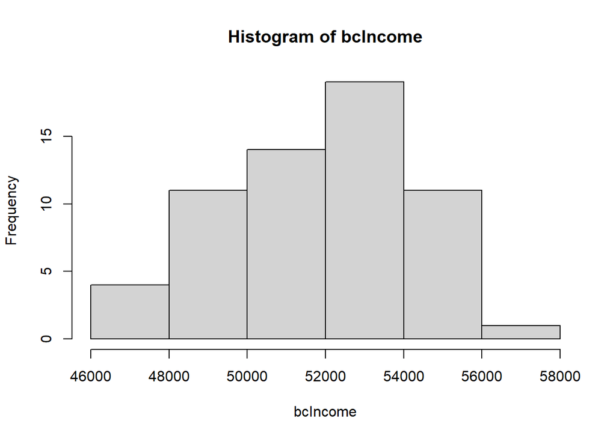

```r
hist(bcIncome)
```

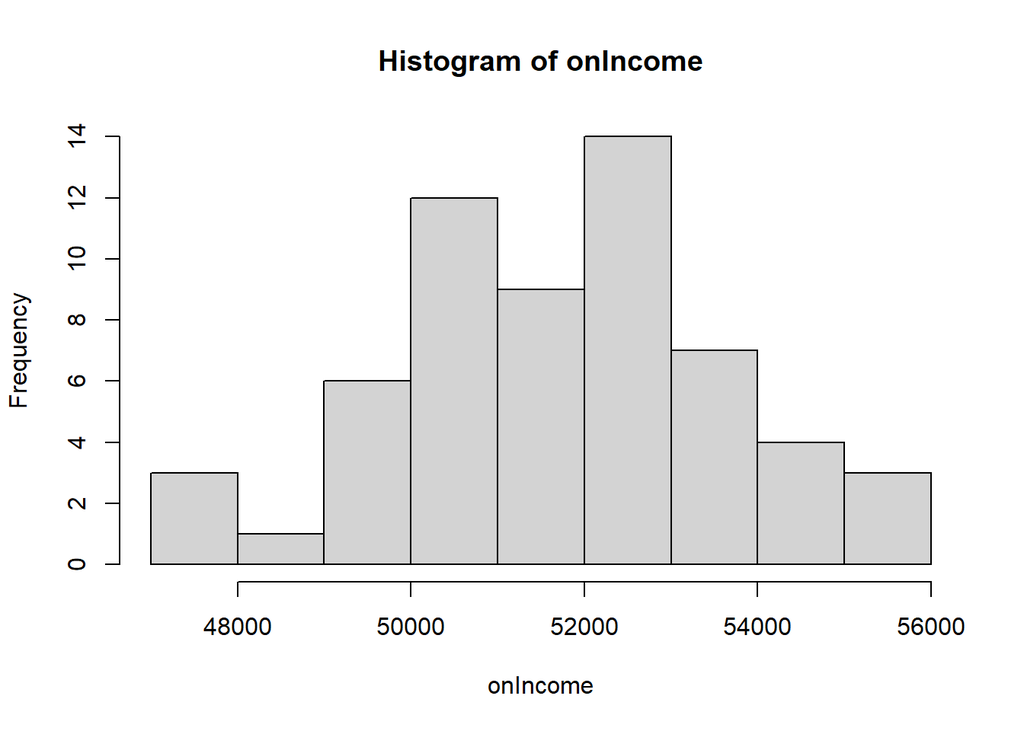

```r
hist(onIncome)
```

*Test for normality*

The Shapiro-Wilk normality test is a formal test for the null hypothesis that the variable is distributed normally. It is usually performed at an $\alpha$ of .05. If the resulting *p* < .05, then we reject the null hypothesis that the variable is distributed normally, i.e., assumption is violated. If *p* $\geq$ .05, then we conclude that the normality assumption is met.

```r
shapiro.test(bcIncome)
```

```
##
##  Shapiro-Wilk normality test
##
## data:  bcIncome
## W = 0.97402, p-value = 0.2285
```

```r
shapiro.test(onIncome)
```

```
##
##  Shapiro-Wilk normality test
##
## data:  onIncome
## W = 0.98866, p-value = 0.858
```

*p* $\geq$ .05 for both `bcIncome` and `onIncome`, $\therefore$ the normality assumption is met.

*Check for homogeneity of variance*

The homogeneity of variance states that the variance of the DV (i.e., income) is the same in the two groups being compared (i.e., BC incomes vs ON incomes). It is a 2-tailed test, typically performed at an $\alpha$ of .05. If the resulting *p* < .05, then we reject the null hypothesis that the variance is the same in the two groups, i.e, the assumption is violated. If *p* $\geq$ .05, then we conclude that the homogeneity of variance assumption is met.

```r
var.test(bcIncome, onIncome, alternative="two.sided")
```

```
##
##  F test to compare two variances
##
## data:  bcIncome and onIncome
## F = 1.5562, num df = 59, denom df = 58, p-value = 0.09383
## alternative hypothesis: true ratio of variances is not equal to 1
## 95 percent confidence interval:
##  0.9269363 2.6097095
## sample estimates:
## ratio of variances
##           1.556225
```

*p* $\geq$ .05, $\therefore$ the homogeneity of variance assumption is met.

*Compute summary statistics*

The `describe` function from the `psych` package provides the most common descriptive statistics needed for reporting purposes. Run `install.packages("psych")` first if you have not used this package before.

```r
library (psych)
describe(bcIncome)
```

```
##    vars  n     mean      sd   median  trimmed     mad      min      max   range
## X1    1 60 51824.04 2349.98 52083.62 51948.23 2572.19 46116.49 56007.31 9890.82
##     skew kurtosis     se
## X1 -0.42    -0.51 303.38
```

```r
describe(onIncome)
```

```
##    vars  n     mean      sd   median  trimmed     mad      min      max   range
## X1    1 59 51755.27 1883.77 51627.57 51785.63 1743.49 47331.58 55770.87 8439.29
##     skew kurtosis     se
## X1 -0.08    -0.43 245.25
```

*Perform Independent Samples t-test if assumptions are met*

All outliers have been removed, and both the normality and homogeneity of variance assumptions were met. Proceed with independent-samples t-test for means.

- See **Analysis Notes** at the end of this page on how to proceed if these assumptions were not met.

```r
t.test(bcIncome, onIncome, paired=FALSE, var.equal=TRUE, alternative="greater")
```

```
##
##  Two Sample t-test
##
## data:  bcIncome and onIncome
## t = 0.17596, df = 117, p-value = 0.4303
## alternative hypothesis: true difference in means is greater than 0
## 95 percent confidence interval:
##  -579.2161       Inf
## sample estimates:
## mean of x mean of y
##  51824.04  51755.27
```

Note that R interprets the input for `alternative` based on the order of the variables entered as input into `t.test()`. By entering `bcIncome` before `onIncome` into `t.test()`, `alternative="greater"` indicates that the alternative hypothesis is that the mean of `bcIncome` is greater than the mean of `onIncome`. If you entered `onIncome` before `bcIncome`, then `alternative="greater"` would indicate an alternative hypotheis that the mean of `onIncome` is greater than the mean of `bcIncome`.

*Interpret results*

The question did not explicitly state an $\alpha$ level (also known as the level of significance), so the level of significance will default to the typical .05 level.

The analysis output indicates that *p* = .43, so we fail to reject the null hypothesis that $\mu_{bc} \leq \mu_{on}$. Therefore, we conclude that BC incomes are not significantly higher than ON incomes.

*APA-style results*

The incomes for BC employees (*M* = 51824.04, *SD* = 2349.98) were not significantly higher than the incomes for ON employees (*M* = 51755.27, *SD* = 1883.77), *t*(117) = 0.18, *p* = .43.

#### **Analysis notes**

**If the normality assumption was violated**, then the Wilcoxon Rank Sum test can be performed as a non-parametric alternative.

```r
wilcox.test(bcIncome, onIncome, paired = FALSE, alternative="greater")
```

```
##
##  Wilcoxon rank sum test with continuity correction
##
## data:  bcIncome and onIncome
## W = 1851, p-value = 0.3344
## alternative hypothesis: true location shift is greater than 0
```

When reporting the results of a Wilcoxon test in APA-style, include the median instead of mean and standard deviation. Note that the test statistic produced for a Wilcoxon test can vary across software packages.

A Wilcoxon rank sum test was performed because the data failed to meet the normality assumption. The incomes for BC employees (*Mdn* = 52083.62) were not significantly higher than the incomes for ON employees (*Mdn* = 51627.57), *W* = 1851, *p* = .33.

**If the normality assumption was met, but the homogeneity of variance assumption was violated**, then perform a Welch’s t-test by setting `var.equal=FALSE` in `t.test()`.

```r
t.test(bcIncome, onIncome, paired=FALSE, var.equal=FALSE, alternative="greater")
```

```
##
##  Welch Two Sample t-test
##
## data:  bcIncome and onIncome
## t = 0.17629, df = 112.46, p-value = 0.4302
## alternative hypothesis: true difference in means is greater than 0
## 95 percent confidence interval:
##  -578.2309       Inf
## sample estimates:
## mean of x mean of y
##  51824.04  51755.27
```

A Welch’s t-test was performed because the data failed to meet the homogeneity of variance assumption. The incomes for BC employees (*M* = 51824.04, *SD* = 2349.98) were not significantly higher than the incomes for ON employees (*M* = 51755.27, *SD* = 1883.77), *t*(112.46) = 0.18, *p* = .43.

## Compare Paired Samples

### **Paired Samples t-Test for Means**

#### **Test description**

Compares the values of 2 scale DVs, DV1 and DV2, from each observation by assessing the mean of the difference scores (DV1 - DV2)

E.g., Compare employee performance from previous year with employee performance for the current year

- DV1 = performance from last year (scale variable)
- DV2 = performance for the current year (scale variable)
- Note that each employee provides data for DV1 and DV2

#### **Assumptions**

- The DVs being compared must both be scale variables; the difference between the two DVs should be meaningful and interpretable.
- The difference measure (DV1 - DV2) has no outliers
- The difference measure (DV1 - DV2) is normally distributed.

#### **R syntax**

Let $d$ represent the difference, DV1 - DV2, for each observation.

*2-tailed test*

- $H_0: \mu_d = 0$
- $H_1: \mu_d \neq 0$

`t.test(y1, y2, paired=TRUE, alternative="two.sided")`

*1-tailed tests*

- $H_0: \mu_d \geq 0$
- $H_1: \mu_d < 0$

`t.test(y1, y2, paired=TRUE, alternative="less")`

- $H_0: \mu_d \leq 0$
- $H_1: \mu_d > 0$

`t.test(y1, y2, paired=TRUE, alternative="greater")`

**Notes:**

- `paired=TRUE` indicates a paired samples t-test.

#### **Non-parametric alternative**

The Wilcoxon Signed Rank test is a non-parametric alternative to the Paired Samples t-test when the normality assumption is violated. It assesses the median of the difference score, DV1 - DV2, across observations.

- `wilcox.test(y1, y2, paired = TRUE, alternative="two.sided")`
- `wilcox.test(y1, y2, paired = TRUE, alternative="less")`
- `wilcox.test(y1, y2, paired = TRUE, alternative="greater")`

#### **Sample analysis**

Among the employees who attended the professional development workshop, was there a significant change in performance from previous year to the current year?

*Identify the null and alternate hypotheses*

2-tailed test:

$H_0: \mu_{d} = 0$

$H_1: \mu_{d} \neq 0$

*Create data frame which only includes employees who attended the professional development workshop*

```r
myDF <- subset(dfHR, dfHR$ProfDev=="Yes")
```

*Create a variable for the difference measure, i.e., change in performance*

```r
myDF$perfChange = myDF$PerfCurr - myDF$PerfPrev
```

*Check the difference measure for outliers*

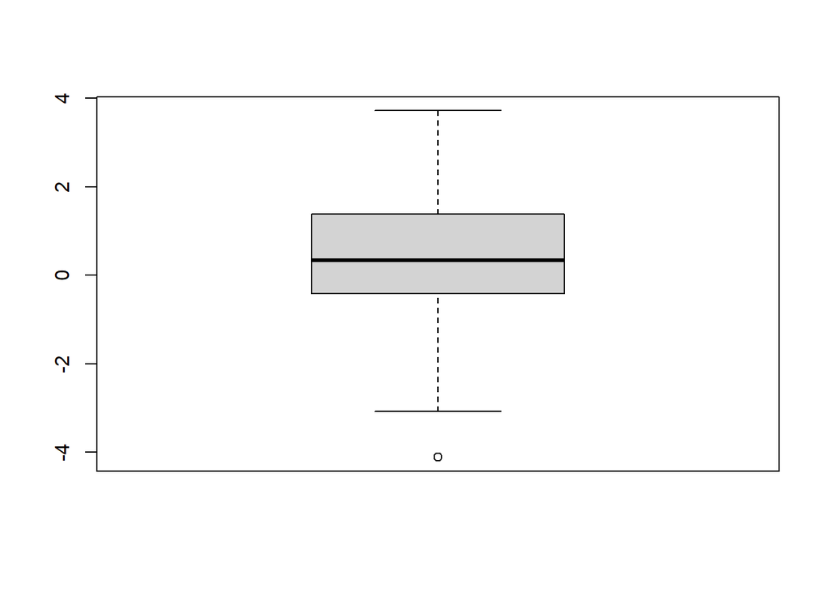

```r
pcOutliers = boxplot(myDF$perfChange)$out
```

One outlier in `perfChange`: -4.11

Remove observation in `myDF` with `perfChange` of -4.11, then re-run boxplot for `perfChange` to confirm that there are no more outliers.

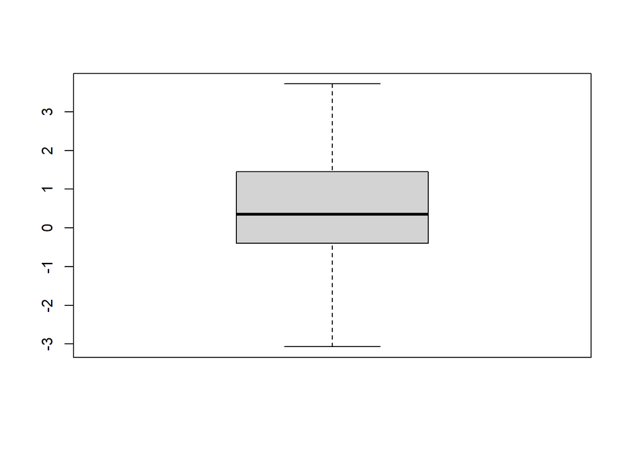

```r
myDF2 = myDF[!(myDF$perfChange %in% pcOutliers),]
pcOutliers = boxplot(myDF2$perfChange)$out
```

*Visualize the data for the difference measure of perfChange*

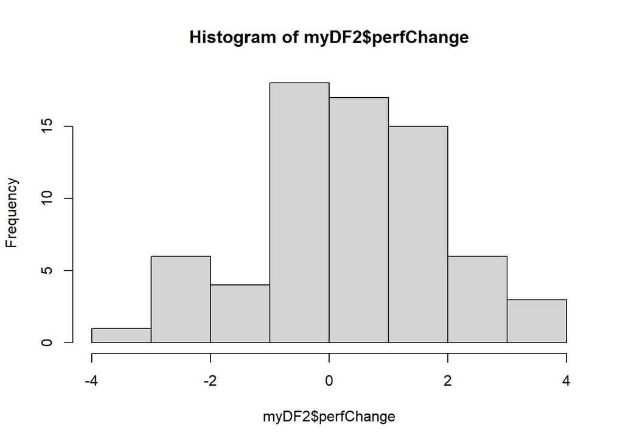

```r
hist(myDF2$perfChange)
```

*Test difference measure for normality*

The Shapiro-Wilk normality test is a formal test for the null hypothesis that the variable is distributed normally. It is usually performed at an $\alpha$ of .05. If the resulting *p* < .05, then we reject the null hypothesis that the variable is distributed normally, i.e., assumption is violated. If *p* $\geq$ .05, then we conclude that the normality assumption is met.

```r
shapiro.test(myDF2$perfChange)
```

```
##
##  Shapiro-Wilk normality test
##
## data:  myDF2$perfChange
## W = 0.98694, p-value = 0.6828
```

*p* = .68, $\therefore$ the normality assumption is met.

*Compute summary statistics*

The `describe` function from the `psych` package provides the most common descriptive statistics needed for reporting purposes. Run `install.packages("psych")` first if you have not used this package before.

```r
library (psych)
describe(myDF2$PerfCurr)
```

```
##    vars  n mean   sd median trimmed  mad  min  max range  skew kurtosis   se
## X1    1 70 7.29 0.97   7.32    7.32 1.02 4.45 9.66  5.21 -0.29    -0.01 0.12
```

```r
describe(myDF2$PerfPrev)
```

```
##    vars  n mean   sd median trimmed  mad  min max range skew kurtosis   se
## X1    1 70 6.94 1.35   6.81    6.91 1.36 4.59  10  5.41 0.22    -0.69 0.16
```

```r
describe(myDF2$perfChange)
```

```
##    vars  n mean  sd median trimmed mad   min  max range  skew kurtosis   se
## X1    1 70 0.34 1.5   0.35    0.37 1.3 -3.07 3.72  6.79 -0.11    -0.36 0.18
```

*Perform Paired Samples t-test if assumptions are met*

The outlier for the difference measure, perfChange, has been removed, and the normality assumption was met. Proceed with paired-samples t-test for means.

- See **Analysis Notes** at the end of this page on how to proceed if the normality assumption was not met.

```r
t.test(myDF2$PerfCurr, myDF2$PerfPrev, paired=TRUE, alternative="two.sided")
```

```
##
##  Paired t-test
##
## data:  myDF2$PerfCurr and myDF2$PerfPrev
## t = 1.9165, df = 69, p-value = 0.05944
## alternative hypothesis: true difference in means is not equal to 0
## 95 percent confidence interval:
##  -0.01410542  0.70353399
## sample estimates:
## mean of the differences
##               0.3447143
```

Note that the mean difference score in the output depends on the order of the variables on the order of the variables entered as input into `t.test()`. By entering `PerfCurr` before `PerfPrev` into `t.test()`, the difference is computed for each observation as `PerfCurr` - `PerfPrev`.

*Interpret results*

The question did not explicitly state an $\alpha$ level (also known as the level of significance), so the level of significance will default to the typical .05 level.

The analysis output indicates that *p* = .06, so we fail to reject the null hypothesis that $\mu_{d} = 0$. Therefore, we conclude that there was no significant change in performance from previous year to the current year for employees who attended the professional development workshop.

*APA-style results*

Among the employees who attended the professional development workshop, there was not a signficant change in performance from last year (*M* = 6.94, *SD* = 1.35) to the current year (*M* = 7.29, *SD* = 0.97), *t*(69) = 1.92, *p* = .06.

#### **Analysis notes**

**If the normality assumption was violated**, then the Wilcoxon Signed Rank test can be performed as a non-parametric alternative.

```r
wilcox.test(myDF2$PerfCurr, myDF2$PerfPrev, paired=TRUE, alternative="two.sided")
```

```
##
##  Wilcoxon signed rank test with continuity correction
##
## data:  myDF2$PerfCurr and myDF2$PerfPrev
## V = 1568.5, p-value = 0.05679
## alternative hypothesis: true location shift is not equal to 0
```

When reporting the results of a Wilcoxon test in APA-style, include the median instead of mean and standard deviation. Note that the test statistic produced for a Wilcoxon test can vary across software packages.

A Wilcoxon signed rank test was performed because the data failed to meet the normality assumption. Among the employees who attended the professional development workshop, there was not a signficant change in performance from last year (*Mdn* = 6.81) to the current year (*Mdn* = 7.32), *V* = 1568.5, *p* = .06.

**If the null hypothesis was rejected for a paired-samples test**, i.e., we concluded a significant change or difference, then it is good practice to include an additional statement about the mean or median of the difference measure (mean difference for a paired sample t-test; median difference for a Wilcoxon signed rank test). For example, if the paired samples t-test above had produced a *p* that was less than .05, then you may add the sentence below to your APA-style interpretation:

The mean difference (current year’s performance - last year’s performance) was 0.34.